# Supplemental Materials 1 - Figures and Tables

**Table S1** Master recession curve constants for each site

|  | SF Q_0 (L/s) | SF abs(k) | QF Q_0 (L/s) | QF abs(k) | QF:SF ratio |
| --- | --- | --- | --- | --- | --- |
| F1 | 11 | 0.05 | 175 | 0.4 | 8.0 |
| DCS | 6 | 0.13 | 9 | 0.5 | 3.8 |
| DCN | 8 | 0.08 | 25 | 0.28 | 3.5 |

**Table S2**  
Rainfall and tile discharge metrics for each site-event. G is growing, NG is non-growing

| WY | Season | Season4 | Event | Site | Rain (mm) | Volume (mm) | R.R. | Response Time (hr) | Peak Flow Rate (mm/day) | Time to Peak Flow (min) | MHRI (mm/day) | Days Since Manure App. | Days Since P App. | TP Load (g/ha) | TP FWMC (ug/L) | SRP Load (g/ha) | SRP FWMC (ug/L) |
| --- | --- | --- | --- | --- | --- | --- | --- | --- | --- | --- | --- | --- | --- | --- | --- | --- | --- |
| 2019 | NG | Fall | 11-02 | F1 | 54.36 | 8.4 | 0.15 | 13.65 | 31.70 | 2085 | 152.40 | 27 | 27 | 4.30 | 50.9 | NA | NA |
| 2019 | NG | Fall | 11-06 | F1 | 10.41 | 2.5 | 0.24 | 18.53 | 3.55 | 150 | 73.15 | 31 | 31 | 3.30 | 133.6 | NA | NA |
| 2019 | NG | Fall | 11-09 | F1 | 30.23 | 18.5 | 0.61 | 4.62 | 38.84 | 330 | 121.92 | 34 | 34 | 43.90 | 236.7 | NA | NA |
| 2019 | NG | Fall | 11-13 | F1 | 13.46 | 2.5 | 0.19 | 10.08 | 1.76 | 465 | 121.92 | 38 | 38 | 2.70 | 110.1 | NA | NA |
| 2019 | NG | Fall | 11-25 | F1 | 35.31 | 48.3 | 1.37 | 11.50 | 33.57 | 2465 | 103.63 | 50 | 50 | 84.50 | 174.9 | NA | NA |
| 2019 | NG | Fall | 12-02 | F1 | 20.57 | 24.4 | 1.19 | NA | 50.65 | 485 | 128.02 | 57 | 57 | 29.20 | 119.8 | NA | NA |
| 2019 | NG | Fall | 12-21 | F1 | NA | 34.2 | NA | NA | 44.68 | 1165 | NA | 76 | 76 | 141.80 | 415.1 | NA | NA |
| 2019 | NG | Fall | 12-31 | F1 | NA | 6.8 | NA | NA | 3.92 | 1455 | NA | 86 | 86 | 11.10 | 162.0 | NA | NA |
| 2019 | NG | Winter | 01-24 | F1 | NA | 21.7 | NA | NA | 37.03 | 790 | NA | 110 | 110 | 3.30 | 15.0 | NA | NA |
| 2019 | NG | Winter | 03-14 | F1 | NA | 13.6 | NA | NA | 31.44 | 1555 | NA | 159 | 159 | 54.10 | 397.1 | NA | NA |
| 2019 | NG | Winter | 03-21 | F1 | NA | 20.6 | NA | NA | 19.78 | 2875 | NA | 166 | 166 | 33.70 | 163.0 | NA | NA |
| 2019 | NG | Spring | 04-09 | F1 | NA | 7.0 | NA | NA | 17.39 | 90 | NA | 185 | 185 | 10.30 | 147.9 | NA | NA |
| 2019 | NG | Spring | 04-15 | F1 | NA | 4.1 | NA | NA | 3.55 | 95 | NA | 191 | 191 | 4.00 | 98.0 | NA | NA |
| 2019 | NG | Spring | 04-20 | F1 | NA | 32.0 | NA | NA | 44.96 | 370 | NA | 196 | 196 | 115.40 | 360.5 | NA | NA |
| 2019 | NG | Spring | 04-26 | F1 | NA | 21.7 | NA | NA | 43.74 | 515 | NA | 202 | 202 | 86.50 | 399.0 | NA | NA |
| 2019 | G | Spring | 05-10 | F1 | NA | 8.0 | NA | NA | 20.38 | 285 | NA | 216 | 216 | 29.90 | 374.0 | NA | NA |
| 2019 | G | Spring | 05-13 | F1 | NA | 6.0 | NA | NA | 4.28 | 330 | NA | 219 | 219 | 3.50 | 57.8 | NA | NA |
| 2019 | G | Spring | 05-19 | F1 | NA | 13.9 | NA | NA | 24.30 | 520 | NA | 225 | 225 | 21.00 | 151.2 | NA | NA |
| 2019 | G | Spring | 05-26 | F1 | NA | 2.1 | NA | NA | 2.66 | 55 | NA | 232 | 7 | 1.30 | 61.4 | NA | NA |
| 2019 | G | Spring | 05-28 | F1 | NA | 8.4 | NA | NA | 9.88 | 200 | 207.26 | 234 | 9 | 5.60 | 66.7 | NA | NA |
| 2019 | G | Spring | 06-05 | F1 | 41.15 | 28.1 | 0.68 | 21.35 | 56.27 | 260 | 225.55 | 242 | 17 | 277.90 | 989.1 | NA | NA |
| 2019 | G | Spring | 06-11 | F1 | 25.40 | 9.8 | 0.39 | 3.17 | 17.13 | 175 | 188.98 | 248 | 23 | 19.60 | 199.1 | NA | NA |
| 2019 | G | Spring | 06-29 | F1 | NA | 3.1 | NA | NA | 4.54 | 50 | NA | 266 | 41 | 4.50 | 147.0 | NA | NA |
| 2019 | G | Summer | 07-06 | F1 | NA | 1.3 | NA | NA | 6.44 | 45 | NA | 273 | 48 | 2.10 | 158.6 | NA | NA |
| 2020 | NG | Fall | 10-07 | F1 | 40.39 | 0.6 | 0.01 | 5.07 | 3.60 | 185 | 170.69 | 1 | 1 | 10.00 | 1559.0 | NA | NA |
| 2020 | NG | Fall | 10-17 | F1 | 66.55 | 22.3 | 0.34 | 6.50 | 45.44 | 350 | 158.50 | 11 | 11 | 154.80 | 693.4 | NA | NA |
| 2020 | NG | Fall | 10-23 | F1 | 12.70 | 0.6 | 0.05 | 4.77 | 2.34 | 315 | 103.63 | 17 | 17 | 2.60 | 475.8 | NA | NA |
| 2020 | NG | Fall | 11-19 | F1 | 10.16 | 5.6 | 0.55 | 2.97 | 3.69 | 4105 | 97.54 | 44 | 44 | 9.50 | 171.4 | NA | NA |
| 2020 | NG | Fall | 11-27 | F1 | 13.72 | 9.7 | 0.71 | 2.45 | 46.64 | 515 | 79.25 | 52 | 52 | 91.60 | 943.1 | NA | NA |
| 2020 | NG | Fall | 12-09 | F1 | 3.81 | 6.0 | 1.57 | NA | 4.29 | 1395 | 67.06 | 64 | 64 | 15.10 | 249.8 | NA | NA |

[output cut: 110 more lines]

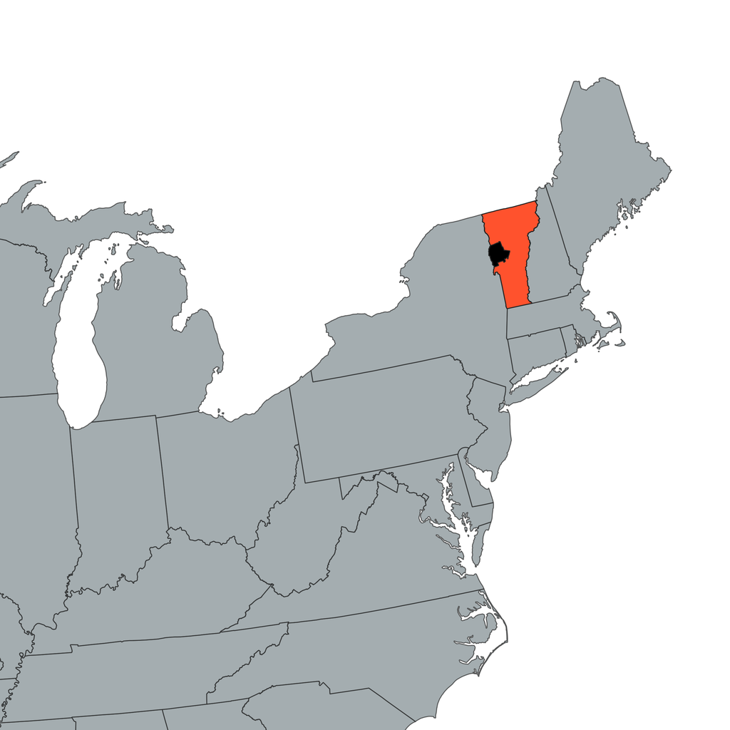

**Figure S1** Map of study location in the northeast United States. State of Vermont in Orange and Addison County, Vermont in Black. Source: Jenny Bower, UVM PSS Department. Base layers obtained from the Vermont Center for Geographic Information and the U.S. Census Bureau.

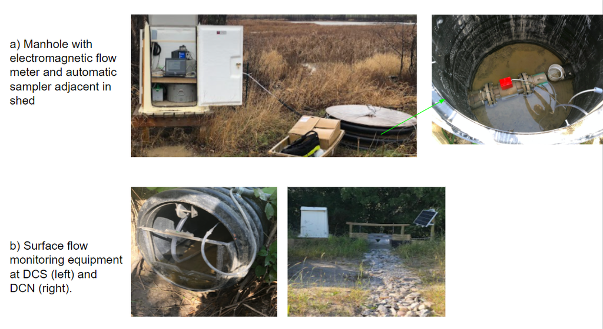

**Figure S2** Images of sampling infrastructure.

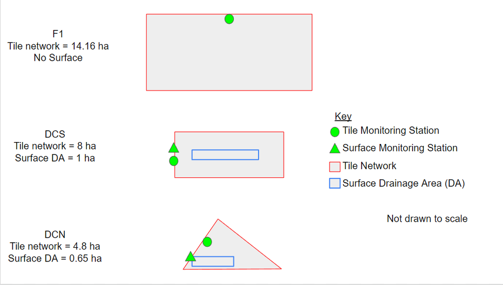

**Figure S3** Field site schematics.

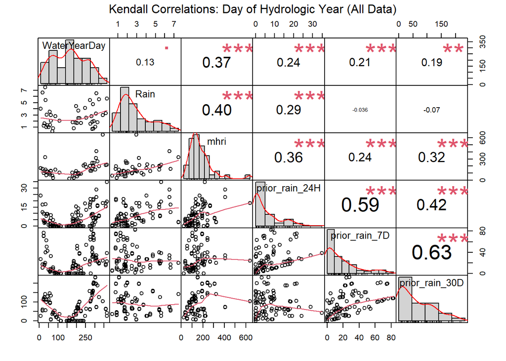

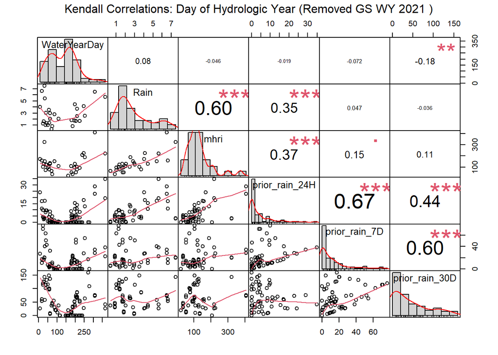

p < .0001 `***`; p < .001 `**`, p < .01 `*`, p < .05 `.

**Figure S4** Kendall correlations between event rainfall metrics and day of hydrologic year (Oct. 1 - Sep. 30), including all data (top) and removing the 2021 WY Growing season (bottom)

**Table S3** Summary statistics for event tile discharge metrics for each site

|  | F1 (N=47) | DCN (N=47) | DCS (N=46) | Overall (N=140) |
| --- | --- | --- | --- | --- |
| Response Time (hr) |  |  |  |  |
| Mean (SD) | 8.16 (6.42) | 7.52 (8.03) | 8.76 (7.73) | 8.11 (7.52) |
| Median [Min, Max] | 4.77 [2.07, 21.4] | 4.17 [0.0300, 24.0] | 6.14 [0.200, 23.9] | 5.08 [0.0300, 24.0] |
| Missing | 28 (59.6%) | 12 (25.5%) | 16 (34.8%) | 56 (40.0%) |
| R.R. |  |  |  |  |
| Mean (SD) | 0.533 (0.431) | 0.536 (0.472) | 0.264 (0.173) | 0.439 (0.399) |
| Median [Min, Max] | 0.510 [0.0100, 1.57] | 0.470 [0.0200, 2.55] | 0.285 [0.0100, 0.670] | 0.340 [0.0100, 2.55] |
| Missing | 26 (55.3%) | 13 (27.7%) | 16 (34.8%) | 55 (39.3%) |
| Peak Flow Rate (mm/day) |  |  |  |  |
| Mean (SD) | 20.3 (18.1) | 31.1 (19.1) | 17.7 (10.9) | 23.0 (17.4) |
| Median [Min, Max] | 17.1 [1.75, 56.3] | 26.7 [6.36, 58.9] | 16.1 [2.65, 36.7] | 17.5 [1.75, 58.9] |
| Missing | 0 (0%) | 4 (8.5%) | 5 (10.9%) | 9 (6.4%) |
| TP Load (g/ha) |  |  |  |  |
| Mean (SD) | 44.3 (62.5) | 77.7 (80.3) | 55.7 (60.3) | 57.4 (68.5) |
| Median [Min, Max] | 14.8 [1.30, 278] | 46.4 [1.50, 330] | 26.3 [2.70, 228] | 28.7 [1.30, 330] |
| Missing | 0 (0%) | 14 (29.8%) | 15 (32.6%) | 29 (20.7%) |
| SRP Load (g/ha) |  |  |  |  |
| Mean (SD) | 23.7 (31.5) | 21.4 (23.2) | 12.0 (14.6) | 17.8 (21.5) |
| Median [Min, Max] | 8.40 [1.10, 85.3] | 15.6 [0, 84.9] | 8.00 [0, 66.6] | 11.5 [0, 85.3] |
| Missing | 40 (85.1%) | 19 (40.4%) | 22 (47.8%) | 81 (57.9%) |

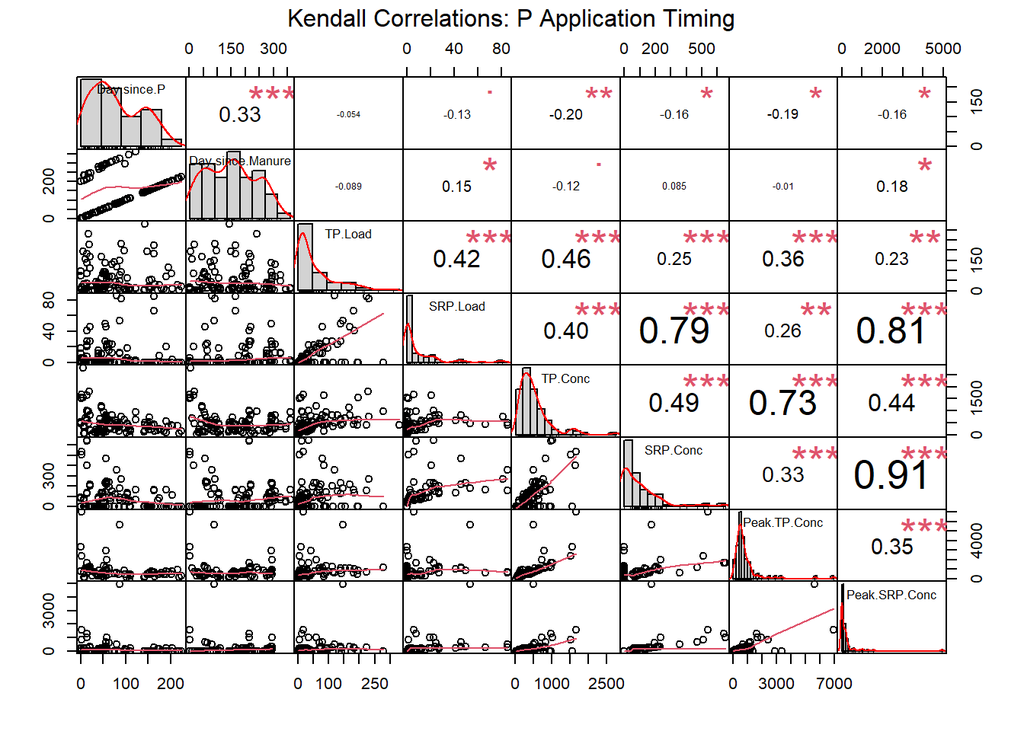

p < .0001 `***`; p < .001 `**`, p < .01 `*`, p < .05 `.`

**Figure S5** Kendall correlations between P application periods (i.e. ‘days since P application’ and ‘days since manure application’) and event tile P discharge metrics

**Table S4** Summary of flow pathway and source connectivity models for events included in the four-component hydrograph separation analysis. Time to peak in hours in parenthesis and all flow components are in mm

|  | Total Rainfall (mm) | Flow Volume (mm) | QF | SF | Old | New | QF old | QF new | SF old | SF new |
| --- | --- | --- | --- | --- | --- | --- | --- | --- | --- | --- |
| DCNSUB05122020 | 16.26 | 3.5 (4.8) | 3.4 (4.8) | 0.1 (14) | 2.5 (4.8) | 1 (5) | 2.4 (4.8) | 1 (5) | 0.1 (14) | 0 (0) |
| DCSSUB05122020 | 16.26 | 1.2 (3.6) | 0.9 (3.6) | 0.3 (10.4) | 0.9 (3.6) | 0.3 (3.6) | 0.6 (3.6) | 0.3 (3.6) | 0.3 (9.9) | 0 (10.2) |
| DCNSUB12012020 | 29.72 | 12.7 (8.8) | 11.9 (8.8) | 0.8 (25) | 6.6 (8.8) | 6.1 (8.8) | 5.8 (8.8) | 6.1 (8.8) | 0.8 (25) | 0 (0) |
| DCNSUB12252020 | 28.19 | 30 (15.2) | 27.7 (15.2) | 2.3 (37.1) | 11.6 (15.2) | 18.4 (15.2) | 9.6 (15.2) | 18.1 (15.2) | 1.9 (37.2) | 0.4 (37.1) |
| DCNSUB01172021 | 20.57 | 4.4 (7.2) | 3.3 (7.2) | 1.1 (45.1) | 1.2 (7.2) | 3.2 (7.2) | 0.6 (7.2) | 2.7 (7.2) | 0.6 (52.1) | 0.5 (45.1) |
| DCNSUB03112021 | 1.02 | 55 (49.6) | 45 (49.6) | 10.1 (89.7) | 13.8 (30.7) | 41.2 (52.8) | 6.8 (30.7) | 38.2 (52.8) | 7 (66.7) | 3.1 (89.8) |
| DCSSUB03112021 | 1.02 | 40 (49.6) | 30.8 (29.8) | 9.2 (79.3) | 12.1 (32.2) | 28 (49.6) | 4.8 (32.2) | 26 (49.6) | 7.3 (63.7) | 1.9 (79.3) |
| DCNSUB04162021 | 44.7 | 20.5 (30.3) | 17.6 (30.3) | 2.9 (57) | 4 (30.3) | 16.5 (30.3) | 1.7 (30.2) | 15.9 (30.3) | 2.3 (57) | 0.6 (53.2) |
| DCSSUB04162021 | 44.7 | 13.8 (28.4) | 11.3 (28.4) | 2.5 (48.2) | 5.4 (28.4) | 8.4 (28.4) | 3.2 (28.4) | 8.1 (28.4) | 2.2 (41.3) | 0.3 (47.4) |
| DCNSUB04222021 | 17.02 | 10.1 (14.6) | 6.8 (14.6) | 3.3 (59.5) | 7.6 (14.6) | 2.5 (14.6) | 4.3 (14.6) | 2.5 (14.6) | 3.3 (59) | 0 (58.1) |
| DCSSUB04222021 | 17.02 | 6.2 (11.5) | 4 (11.5) | 2.2 (44.1) | 3.6 (12.2) | 2.5 (11.5) | 1.6 (12.2) | 2.4 (11.5) | 2.1 (39.5) | 0.2 (43.1) |
| DCNSUB04302021 | 29.72 | 29.7 (8.2) | 24.2 (8.2) | 5.5 (48.2) | 13.6 (8.2) | 16.2 (8.2) | 8.6 (8.2) | 15.6 (8.2) | 4.9 (49.8) | 0.6 (47.7) |
| DCSSUB04302021 | 30.23 | 20.6 (9.8) | 16.6 (9.8) | 4 (43.1) | 9.1 (10) | 11.5 (9.8) | 5.7 (10) | 10.9 (9.8) | 3.4 (35.2) | 0.6 (42.8) |
| DCNSUB05062021 | 25.15 | 20.8 (13.9) | 17.5 (13.9) | 3.3 (40) | 11.9 (13.8) | 8.9 (13.9) | 8.6 (13.8) | 8.9 (13.9) | 3.3 (40) | 0 (36.8) |
| DCSSUB05062021 | 24.89 | 13.4 (15.4) | 10.9 (15.4) | 2.5 (30.9) | 6.1 (15.9) | 7.3 (14.9) | 3.8 (15.9) | 7.1 (14.9) | 2.3 (27.2) | 0.2 (30.6) |
| DCNSUB07022021 | 54.36 | 18 (4) | 16.6 (4) | 1.3 (20.1) | 6.8 (3.9) | 11.2 (4) | 5.5 (3.9) | 11.2 (4) | 1.3 (20.1) | 0 (0) |
| DCSSUB07022021 | 55.63 | 15.8 (3.6) | 15.2 (3.6) | 0.6 (22) | 6.4 (6) | 9.4 (9.9) | 5.8 (6) | 9.4 (9.9) | 0.6 (22) | 0 (0) |
| DCNSUB07032021 | 29.21 | 8.4 (0.9) | 4.8 (0.9) | 3.5 (19.3) | 7.5 (0.8) | 0.9 (1.3) | 4 (0.8) | 0.8 (1.3) | 3.5 (19.1) | 0 (19.4) |
| DCSSUB07032021 | 31.75 | 8.8 (1.6) | 5.5 (1.6) | 3.4 (21.9) | 7.5 (2) | 1.4 (1.6) | 4.1 (2) | 1.3 (1.6) | 3.3 (21.8) | 0 (0.5) |
| DCNSUB07092021 | 28.19 | 8.9 (6.2) | 8 (6.2) | 1 (15) | 4.1 (6.2) | 4.8 (6.2) | 3.2 (6.2) | 4.8 (6.2) | 1 (15) | 0 (13.8) |
| DCSSUB07092021 | 28.19 | 8.6 (6.9) | 7.4 (6.8) | 1.2 (17.4) | 4.6 (7.7) | 4 (6.9) | 3.5 (7.7) | 3.9 (6.9) | 1.1 (15.7) | 0 (17.1) |
| DCNSUB07132021 | 18.8 | 2.5 (2.3) | 2.2 (2.3) | 0.3 (10) | 1.7 (2.3) | 0.7 (2.6) | 1.5 (2.3) | 0.7 (2.6) | 0.3 (10) | 0 (0.3) |
| DCSSUB07132021 | 18.8 | 2.1 (1.8) | 1.7 (1.8) | 0.4 (10) | 1.4 (1.8) | 0.7 (2) | 1 (1.8) | 0.7 (2) | 0.4 (10) | 0 (0.1) |
| DCNSUB07182021 | 47.24 | 21.7 (10.1) | 20 (10.1) | 1.7 (22) | 6.9 (4.2) | 14.7 (10.1) | 5.3 (4.2) | 14.7 (10.1) | 1.7 (22) | 0 (0.5) |
| DCSSUB07182021 | 49.78 | 18.6 (11.8) | 16.7 (11.8) | 2 (28.5) | 7.4 (12.6) | 11.2 (10.4) | 5.5 (12.6) | 11.2 (10.4) | 2 (27.1) | 0 (28.2) |
| DCS Sum | 318.27 | 149.1 | 121 | 28.3 | 64.5 | 84.7 | 39.6 | 81.3 | 25 | 3.2 |
| DCN Sum | 390.15 | 246.2 | 209 | 37.2 | 99.8 | 146.3 | 67.9 | 141.2 | 32 | 5.2 |
| Mean | 28.34 | 15.81 | 13.2 | 2.62 | 6.57 | 9.24 | 4.3 | 8.9 | 2.28 | 0.34 |
| S.D. | 14.58 | 12.65 | 10.61 | 2.51 | 3.82 | 9.61 | 2.49 | 9.01 | 1.92 | 0.71 |

|  | Volume | Rain | RR | 24 hr Rain | 7 day Rain | 30 day Rain | Peak Rainfall Intensity | Response Time | Time to Peak Flow | Peak Flow Rate | TP Load | SRP Load | PPL | QF | QF_TtP | SF | SF_TtP | old | old_TtP | new | new_TtP | QF_old | QF_old_TtP | QF_new | QF_new_TtP | SF_old | SF_old_TtP | SF_new |
| --- | --- | --- | --- | --- | --- | --- | --- | --- | --- | --- | --- | --- | --- | --- | --- | --- | --- | --- | --- | --- | --- | --- | --- | --- | --- | --- | --- | --- |
| Volume |  |  |  |  |  |  |  |  |  |  |  |  |  |  |  |  |  |  |  |  |  |  |  |  |  |  |  |  |
| Rain | -0.14 |  |  |  |  |  |  |  |  |  |  |  |  |  |  |  |  |  |  |  |  |  |  |  |  |  |  |  |
| RR | 0.78**** | -0.56** |  |  |  |  |  |  |  |  |  |  |  |  |  |  |  |  |  |  |  |  |  |  |  |  |  |  |
| 24 hr Rain | -0.38 | 0.62** | -0.39 |  |  |  |  |  |  |  |  |  |  |  |  |  |  |  |  |  |  |  |  |  |  |  |  |  |
| 7 day Rain | -0.46* | 0.12 | -0.36 | 0.41* |  |  |  |  |  |  |  |  |  |  |  |  |  |  |  |  |  |  |  |  |  |  |  |  |
| 30 day Rain | -0.37 | 0.24 | -0.40* | 0.25 | 0.67*** |  |  |  |  |  |  |  |  |  |  |  |  |  |  |  |  |  |  |  |  |  |  |  |
| Peak Rainfall Intensity | -0.43* | 0.38 | -0.40* | 0.47* | 0.34 | 0.61** |  |  |  |  |  |  |  |  |  |  |  |  |  |  |  |  |  |  |  |  |  |  |
| Response Time | -0.41* | 0.15 | -0.46* | 0.05 | 0.28 | 0.37 | 0.25 |  |  |  |  |  |  |  |  |  |  |  |  |  |  |  |  |  |  |  |  |  |
| Time to Peak Flow | 0.78**** | -0.35 | 0.82**** | -0.44* | -0.46* | -0.52** | -0.55** | -0.43* |  |  |  |  |  |  |  |  |  |  |  |  |  |  |  |  |  |  |  |  |
| Peak Flow Rate | 0.63*** | 0.36 | 0.26 | -0.01 | -0.02 | 0.12 | 0.04 | -0.23 | 0.26 |  |  |  |  |  |  |  |  |  |  |  |  |  |  |  |  |  |  |  |
| TP Load | 0.90**** | -0.15 | 0.59** | -0.52** | -0.49* | -0.24 | -0.47* | -0.33 | 0.69*** | 0.64*** |  |  |  |  |  |  |  |  |  |  |  |  |  |  |  |  |  |  |
| SRP Load | 0.92**** | -0.27 | 0.74**** | -0.51** | -0.48* | -0.28 | -0.41* | -0.45* | 0.71**** | 0.60** | 0.93**** |  |  |  |  |  |  |  |  |  |  |  |  |  |  |  |  |  |
| PPL | 0.85**** | -0.09 | 0.50* | -0.51** | -0.47* | -0.21 | -0.47* | -0.25 | 0.64*** | 0.63*** | 0.99**** | 0.86**** |  |  |  |  |  |  |  |  |  |  |  |  |  |  |  |  |
| QF | 0.99**** | -0.07 | 0.73**** | -0.37 | -0.49* | -0.36 | -0.37 | -0.41* | 0.74**** | 0.66*** | 0.90**** | 0.92**** | 0.85**** |  |  |  |  |  |  |  |  |  |  |  |  |  |  |  |
| QF_TtP | 0.77**** | -0.28 | 0.76**** | -0.42* | -0.45* | -0.51** | -0.55** | -0.30 | 0.96**** | 0.24 | 0.68*** | 0.68*** | 0.65*** | 0.74**** |  |  |  |  |  |  |  |  |  |  |  |  |  |  |
| SF | 0.85**** | -0.44* | 0.85**** | -0.37 | -0.29 | -0.35 | -0.59** | -0.35 | 0.80**** | 0.35 | 0.75**** | 0.74**** | 0.72**** | 0.78**** | 0.74**** |  |  |  |  |  |  |  |  |  |  |  |  |  |
| SF_TtP | 0.76**** | -0.37 | 0.72**** | -0.54** | -0.46* | -0.56** | -0.70**** | -0.25 | 0.88**** | 0.14 | 0.68*** | 0.62*** | 0.67*** | 0.71**** | 0.87**** | 0.85**** |  |  |  |  |  |  |  |  |  |  |  |  |
| old | 0.85**** | -0.08 | 0.52** | -0.29 | -0.24 | -0.22 | -0.42* | -0.29 | 0.50* | 0.66*** | 0.84**** | 0.80**** | 0.83**** | 0.83**** | 0.48* | 0.78**** | 0.61** |  |  |  |  |  |  |  |  |  |  |  |
| old_TtP | 0.67*** | -0.21 | 0.63*** | -0.40* | -0.45* | -0.55** | -0.57** | -0.33 | 0.95**** | 0.22 | 0.62** | 0.56** | 0.62** | 0.64*** | 0.94**** | 0.67*** | 0.85**** | 0.43* |  |  |  |  |  |  |  |  |  |  |
| new | 0.98**** | -0.16 | 0.82**** | -0.39 | -0.52** | -0.40* | -0.39 | -0.43* | 0.83**** | 0.56** | 0.86**** | 0.90**** | 0.80**** | 0.98**** | 0.82**** | 0.81**** | 0.76**** | 0.73**** | 0.71**** |  |  |  |  |  |  |  |  |  |
| new_TtP | 0.80**** | -0.34 | 0.84**** | -0.41* | -0.47* | -0.53** | -0.54** | -0.44* | 0.99**** | 0.27 | 0.68*** | 0.71**** | 0.63*** | 0.76**** | 0.96**** | 0.80**** | 0.88**** | 0.51** | 0.94**** | 0.85**** |  |  |  |  |  |  |  |  |
| QF_old | 0.68*** | 0.18 | 0.21 | -0.20 | -0.21 | -0.12 | -0.19 | -0.20 | 0.21 | 0.72**** | 0.72**** | 0.68*** | 0.71**** | 0.71**** | 0.22 | 0.43* | 0.30 | 0.90**** | 0.18 | 0.54** | 0.22 |  |  |  |  |  |  |  |
| QF_old_TtP | 0.67*** | -0.21 | 0.63*** | -0.41* | -0.45* | -0.55** | -0.57** | -0.33 | 0.95**** | 0.22 | 0.62** | 0.56** | 0.62** | 0.64*** | 0.94**** | 0.67*** | 0.85**** | 0.43* | 1.00**** | 0.71**** | 0.94**** | 0.18 |  |  |  |  |  |  |
| QF_new | 0.98**** | -0.13 | 0.81**** | -0.38 | -0.52** | -0.39 | -0.38 | -0.43* | 0.82**** | 0.58** | 0.86**** | 0.90**** | 0.81**** | 0.98**** | 0.81**** | 0.80**** | 0.75**** | 0.74**** | 0.71**** | 1.00**** | 0.83**** | 0.56** | 0.71**** |  |  |  |  |  |
| QF_new_TtP | 0.80**** | -0.34 | 0.84**** | -0.41* | -0.47* | -0.53** | -0.54** | -0.44* | 0.99**** | 0.27 | 0.68*** | 0.71**** | 0.63*** | 0.76**** | 0.96**** | 0.80**** | 0.88**** | 0.51** | 0.94**** | 0.85**** | 1.00**** | 0.22 | 0.94**** | 0.83**** |  |  |  |  |
| SF_old | 0.81**** | -0.38 | 0.75**** | -0.32 | -0.20 | -0.28 | -0.59** | -0.31 | 0.73**** | 0.37 | 0.74**** | 0.70**** | 0.72**** | 0.73**** | 0.66*** | 0.98**** | 0.82**** | 0.82**** | 0.62*** | 0.74**** | 0.73**** | 0.48* | 0.62*** | 0.73**** | 0.73**** |  |  |  |
| SF_old_TtP | 0.67*** | -0.29 | 0.57** | -0.54** | -0.46* | -0.57** | -0.70*** | -0.14 | 0.78**** | 0.06 | 0.61** | 0.52** | 0.63*** | 0.62*** | 0.78**** | 0.75**** | 0.97**** | 0.56** | 0.79**** | 0.66*** | 0.77**** | 0.29 | 0.79**** | 0.65*** | 0.77**** | 0.73**** |  |  |
| SF_new | 0.83**** | -0.52** | 0.95**** | -0.45* | -0.47* | -0.48* | -0.50* | -0.40* | 0.85**** | 0.24 | 0.66*** | 0.74**** | 0.60** | 0.78**** | 0.82**** | 0.88**** | 0.82**** | 0.54** | 0.69*** | 0.87**** | 0.87**** | 0.23 | 0.69*** | 0.85**** | 0.87**** | 0.78**** | 0.70*** |  |
| SF_new_TtP | 0.68*** | -0.44* | 0.66*** | -0.59** | -0.37 | -0.47* | -0.73**** | -0.22 | 0.83**** | 0.08 | 0.63*** | 0.55** | 0.64*** | 0.61** | 0.83**** | 0.82**** | 0.95**** | 0.54** | 0.83**** | 0.68*** | 0.82**** | 0.23 | 0.83**** | 0.66*** | 0.82**** | 0.78**** | 0.93**** | 0.77**** |

p < .0001 `****`; p < .001 `***`, p < .01 `**`, p < .05 `*`

**Table S6** Summary statistics for High and Low intensity rainfall pulses during events

|  | High (N=47) | Low (N=81) |
| --- | --- | --- |
| pulse_length (hours) |  |  |
| Mean (SD) | 5.47 (3.81) | 1.55 (1.81) |
| Median [Min, Max] | 5.00 [0.500, 14.5] | 0.500 [0.500, 8.50] |
| pulse_sums (mm) |  |  |
| Mean (SD) | 15.9 (14.0) | 1.36 (1.88) |
| Median [Min, Max] | 15.0 [1.52, 64.5] | 0.508 [0.254, 7.87] |
| pulse_max (mm/day) |  |  |
| Mean (SD) | 179 (118) | 23.8 (16.0) |
| Median [Min, Max] | 122 [73.2, 512] | 12.2 [12.2, 61.0] |
| meanTP (g/ha/day) |  |  |
| Mean (SD) | 98.2 (129) | 35.5 (41.8) |
| Median [Min, Max] | 55.0 [0.537, 602] | 21.9 [1.68, 245] |
| meanSRP (g/ha/day) |  |  |
| Mean (SD) | 30.8 (50.7) | 9.22 (12.9) |
| Median [Min, Max] | 16.2 [0.169, 305] | 5.77 [0.510, 81.8] |
| meanPP (g/ha/day) |  |  |
| Mean (SD) | 67.6 (84.1) | 26.2 (29.8) |
| Median [Min, Max] | 30.9 [0.306, 349] | 17.1 [0.587, 163] |
| maxFlow (mm/day) |  |  |
| Mean (SD) | 24.5 (17.9) | 9.13 (7.72) |
| Median [Min, Max] | 25.1 [0.607, 58.9] | 7.50 [1.38, 44.4] |

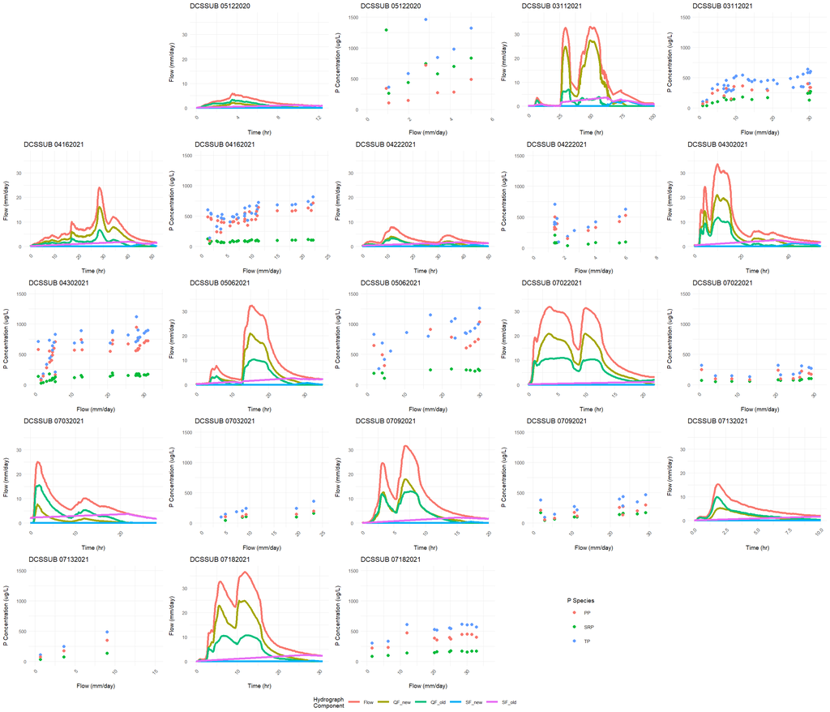

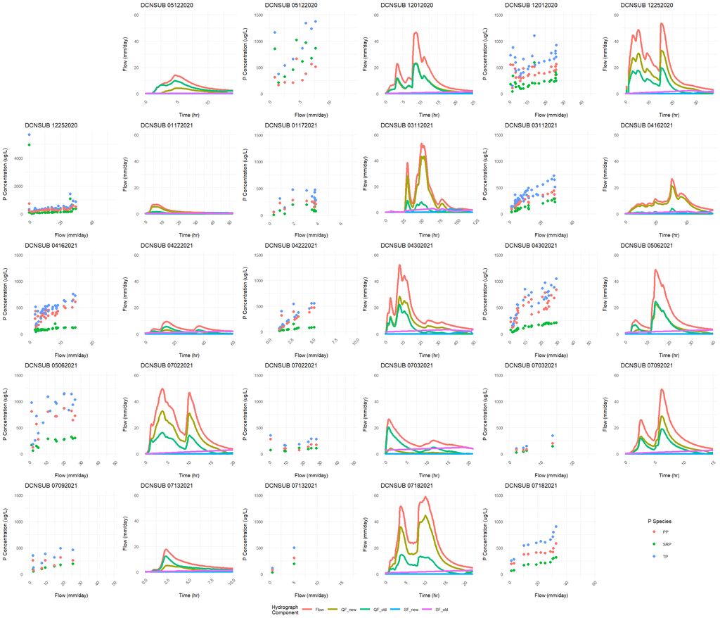

**Figure S6** Four component hydrograph separation (left) and P concentrations in event samples as a function of tile flow rate (right) for events included in the four-component hydrograph separation analysis at DCS (top) and DCN (bottom). F1 was omitted from this figure because only 1 event was in-cluded in the four-component hydrograph separation analysis. Note that the scale for DCN on 12/25/2020 is extended to show the high P concentrations